# Reproducible Research: Peer Assessment 1

## Loading and preprocessing the data

At the very begining, we need to check the existence of files in a certain directory. Here come the codes.

```r
wd <- getwd()
 if(!file.exists("./data")){
+     dir.create("./data")
}
if(!file.exists("./data/repdata_data_activity.zip")){
+     url <- "https://d396qusza40orc.cloudfront.net/repdata%2Fdata%2Factivity.zip"
+     download.file(url, destfile="./data/repdata_data_activity.zip", method="curl")
}
 if(!file.exists("./data/activity.csv")){
+     zipF<-file.choose()
+     outDir<-"./data"
+     unzip(zipF,exdir=outDir)
}
```

Now, let’s load the data!

```r
setwd("./data")
rawdata <- read.csv("activity.csv")
```

To preprocess the data set, here we only need to change the format of date *from factor to date*.

```r
#Take a glance first
summary(rawdata)
```

```
##      steps                date          interval
##  Min.   :  0.00   2012-10-01:  288   Min.   :   0.0
##  1st Qu.:  0.00   2012-10-02:  288   1st Qu.: 588.8
##  Median :  0.00   2012-10-03:  288   Median :1177.5
##  Mean   : 37.38   2012-10-04:  288   Mean   :1177.5
##  3rd Qu.: 12.00   2012-10-05:  288   3rd Qu.:1766.2
##  Max.   :806.00   2012-10-06:  288   Max.   :2355.0
##  NA's   :2304     (Other)   :15840
```

```r
str(rawdata)
```

```
## 'data.frame':    17568 obs. of  3 variables:
##  $ steps   : int  NA NA NA NA NA NA NA NA NA NA ...
##  $ date    : Factor w/ 61 levels "2012-10-01","2012-10-02",..: 1 1 1 1 1 1 1 1 1 1 ...
##  $ interval: int  0 5 10 15 20 25 30 35 40 45 ...
```

```r
#preprocess it
mydata <- rawdata
mydata$date <- as.Date(mydata$date)
```

## What is mean total number of steps taken per day?

Before following calculations, we need to drop all the missing values in the data set.

```r
nona <- mydata[complete.cases(mydata),]
str(nona)
```

```
## 'data.frame':    15264 obs. of  3 variables:
##  $ steps   : int  0 0 0 0 0 0 0 0 0 0 ...
##  $ date    : Date, format: "2012-10-02" "2012-10-02" ...
##  $ interval: int  0 5 10 15 20 25 30 35 40 45 ...
```

Now, calculate the total number of steps taken per day.

```r
#Create a new dataframe to store the total number of steps each day
totalsteps <- aggregate(nona$steps, by=list(Date=nona$date), FUN=sum)
names(totalsteps)<-c("Date","Steps")
totalsteps
```

```
##          Date Steps
## 1  2012-10-02   126
## 2  2012-10-03 11352
## 3  2012-10-04 12116
## 4  2012-10-05 13294
## 5  2012-10-06 15420
## 6  2012-10-07 11015
## 7  2012-10-09 12811
## 8  2012-10-10  9900
## 9  2012-10-11 10304
## 10 2012-10-12 17382
## 11 2012-10-13 12426
## 12 2012-10-14 15098
## 13 2012-10-15 10139
## 14 2012-10-16 15084
```

[output cut: 39 more lines]

Then, make a histgram of the total number of steps taken each day.

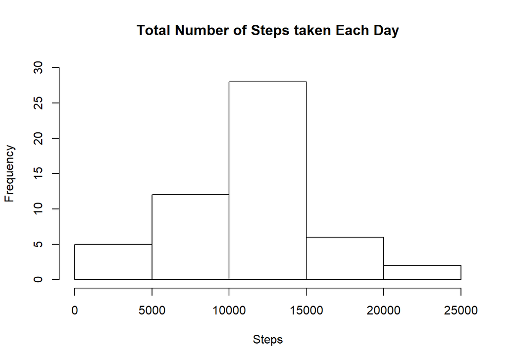

```r
hist(totalsteps$Steps, main="Total Number of Steps taken Each Day", xlab="Steps", ylim= c(0,30))
```

```r
#Calculate mean and median
mean <- mean(totalsteps$Steps)
median <- median(totalsteps$Steps)
```

## What is the average daily activity pattern?

To understand the average daily activity pattern, we coudl first make a time series plot (i.e. type = “l”) of the 5-minute interval (x-axis) and the average number of steps taken, averaged across all days (y-axis).

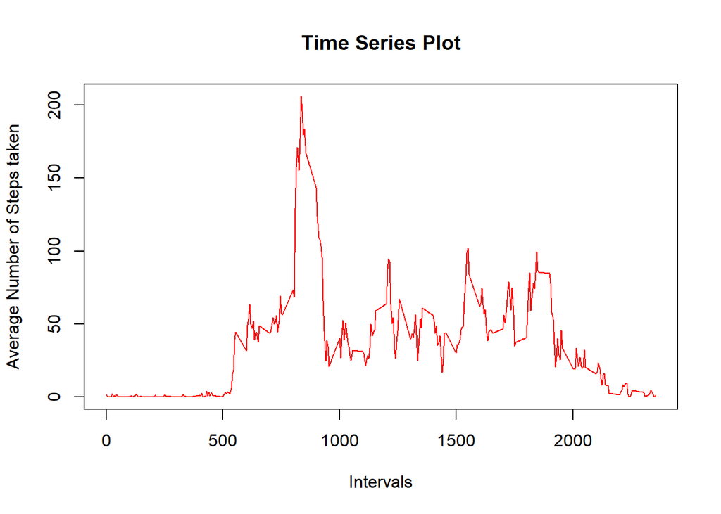

```r
#calculate the average number of steps taken
pattern <- aggregate(nona$steps, by=list(Intervals = nona$interval),FUN=mean)
names(pattern) <- c("Intervals","AvgSteps")
#make a plot
with(pattern, plot(Intervals, AvgSteps, type="n", ylab="Average Number of Steps taken", xlab="Intervals",main="Time Series Plot"))
with(pattern, lines(Intervals, AvgSteps, type="l",col="red"))
```

Also, we could tell which 5-minute interval, on average across all the days in the dataset, contains the maximum number of steps.

```r
maxium <- pattern$Intervals[which(pattern$AvgSteps==max(pattern$AvgSteps))]
```

The 5-minute interval which contains the maximum number of steps is 835.

## Imputing missing values

Before imputing missing values, we could calculate and report the total number of missing values in the dataset (i.e. the total number of rows with NA)

```r
totalNA <- sum(is.na(mydata$steps))
```

The total number of missing values in the dataset is 2304.

```r
newdata <- mydata
na <- is.na(newdata$steps)
newdata[na, ]$steps <- mean(pattern$AvgSteps)
```

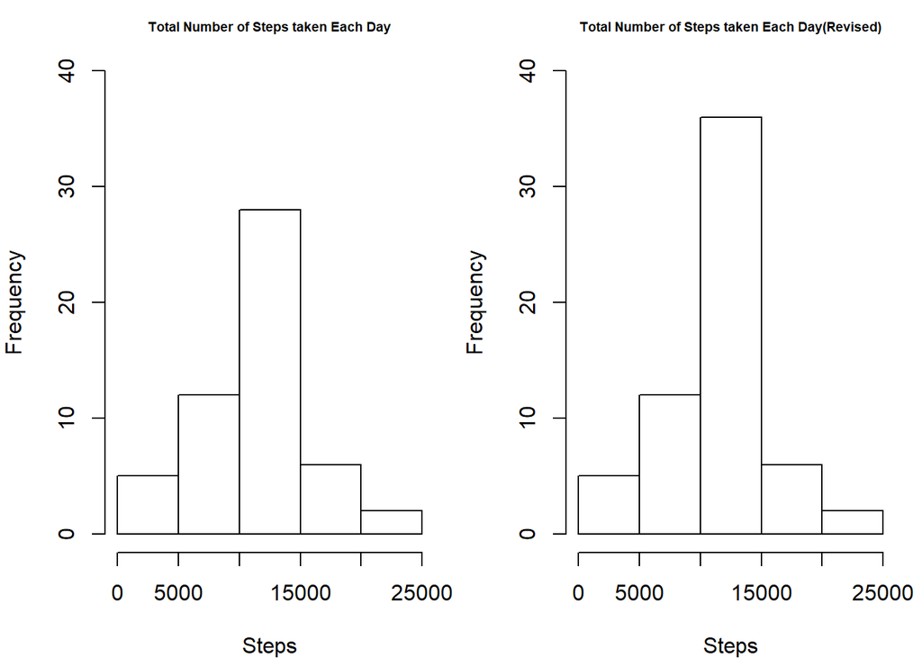

```r
#make a new histgram
totalsteps2 <- aggregate(newdata$steps, by=list(Date=newdata$date), FUN=sum)
names(totalsteps2)<-c("Date","Steps")
par(mfrow=c(1,2),mar=c(4,4,2,1),cex.main=0.6)
hist(totalsteps$Steps, main="Total Number of Steps taken Each Day", xlab="Steps", ylim= c(0,40))
hist(totalsteps2$Steps, main="Total Number of Steps taken Each Day(Revised)", xlab="Steps", ylim= c(0,40))
```

```r
#recalculate the mean and the median
mean2 <- mean(totalsteps2$Steps)
median2 <- median(totalsteps2$Steps)
```

## Are there differences in activity patterns between weekdays and weekends?

Create a new factor variable in the dataset with two levels - “weekday” and “weekend” indicating whether a given date is a weekday or weekend day.

```r
Sys.setlocale("LC_TIME","US")
weekdata <- newdata
weekdata$weekday <- weekdays(weekdata$date)
weekdata$type <- with(weekdata, ifelse(weekday=="Saturday"|weekday=="Sunday","weekend","weekday"))
weekdata$type <- as.factor(weekdata$type)
```

Finally, make a panel plot containing a time series plot of the 5-minute interval (x-axis) and the average number of steps taken, averaged across all weekday days or weekend days (y-axis).

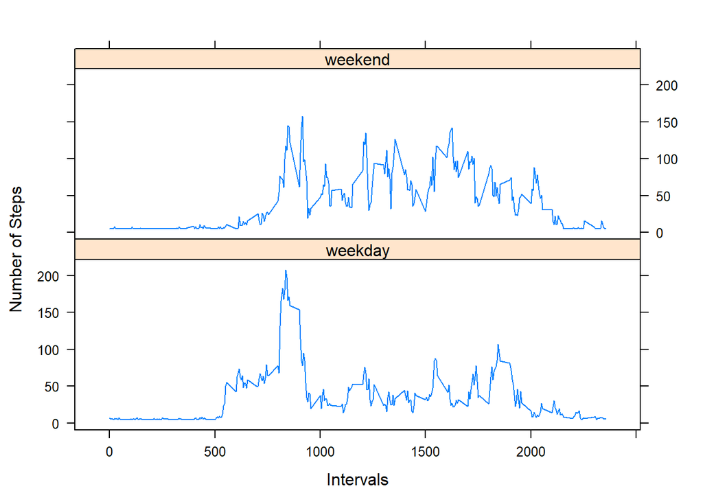

```r
pattern2 <- aggregate(weekdata$steps, by=list(Intervals = weekdata$interval, Type=weekdata$type),FUN=mean)
names(pattern2) <- c("Intervals","Type","AvgSteps")
library(lattice)
xyplot(AvgSteps~Intervals|Type,data=pattern2,layout=c(1,2),type="l",ylab="Number of Steps")
```

END